# Practical Machine Learning Course Project

A. Solomon

2023-03-20

## Background

Using devices such as Jawbone Up, Nike FuelBand, and Fitbit, it is now possible to collect a large amount of data about personal activity relatively inexpensively. These type of devices are part of the quantified self movement – a group of enthusiasts who take measurements about themselves regularly to improve their health, to find patterns in their behavior, or because they are tech geeks. One thing that people regularly do is quantify how much of a particular activity they do, but they rarely quantify how well they do it.

## Data Analysis

In this project, we use data from accelerometers on the belt, forearm, arm, and dumbell of 6 participants. The participants were asked to perform barbell lifts correctly and incorrectly in 5 different ways. The data for this project come from this source: http://groupware.les.inf.puc-rio.br/har.

The goal of this project is to predict the manner in which they did the exercise.A tidy data is created by removing columns with little or no data at all. Cross validation will be done by creating training and test data from training data.

```r
library(ggplot2)
library(caret)
library(randomForest)
library(rpart)
library(rpart.plot)
library(corrplot)
train_file <-"https://d396qusza40orc.cloudfront.net/predmachlearn/pml-training.csv"
test_file <- "https://d396qusza40orc.cloudfront.net/predmachlearn/pml-testing.csv"
train_data <- "./data/pml-training.csv"
test_data  <- "./data/pml-testing.csv"
if (!file.exists("./data")) {
  dir.create("./data")
}
if (!file.exists(train_data)) {
  download.file(train_file, destfile=train_data, method="curl")
}
if (!file.exists(test_data)) {
  download.file(test_file, destfile=test_data, method="curl")
}
```

```r
trainFile <- read.csv("./data/pml-training.csv")
testFile <- read.csv("./data/pml-testing.csv")
dim(trainFile)
```

```
## [1] 19622   160
```

```r
dim(testFile)
```

```
## [1]  20 160
```

```r
trainFile <- trainFile[,colMeans(is.na(trainFile)) < .9]
trainFile <- trainFile[,-c(1:7)]

nzero <- nearZeroVar(trainFile)
trainFile <- trainFile[,-nzero]
dim(trainFile)
```

```
## [1] 19622    53
```

### Cross Validation

The training data is divided into a training set (0.7) and cross validation set (0.3).

```r
inTrain <- createDataPartition(y=trainFile$classe, p=0.7, list=F)
train <- trainFile[inTrain,]
valid <- trainFile[-inTrain,]
control <- trainControl(method="cv", number=3, verboseIter=F)
```

```r
randomForest <- train(classe~., data=train, method="rf", trControl = control, tuneLength = 5)

prediction_RF <- predict(randomForest, valid)
TRF <- confusionMatrix(prediction_RF, factor(valid$classe))
TRF
```

```
## Confusion Matrix and Statistics
##
##           Reference
## Prediction    A    B    C    D    E
##          A 1672    6    0    0    0
##          B    2 1132    8    0    0
##          C    0    1 1013   11    0
##          D    0    0    5  953    6
##          E    0    0    0    0 1076
##
## Overall Statistics
##
##                Accuracy : 0.9934
##                  95% CI : (0.991, 0.9953)
##     No Information Rate : 0.2845
##     P-Value [Acc > NIR] : < 2.2e-16
##
##                   Kappa : 0.9916
##
##  Mcnemar's Test P-Value : NA
##
## Statistics by Class:
##
##                      Class: A Class: B Class: C Class: D Class: E
## Sensitivity            0.9988   0.9939   0.9873   0.9886   0.9945
## Specificity            0.9986   0.9979   0.9975   0.9978   1.0000
## Pos Pred Value         0.9964   0.9912   0.9883   0.9886   1.0000
## Neg Pred Value         0.9995   0.9985   0.9973   0.9978   0.9988
## Prevalence             0.2845   0.1935   0.1743   0.1638   0.1839
## Detection Rate         0.2841   0.1924   0.1721   0.1619   0.1828
## Detection Prevalence   0.2851   0.1941   0.1742   0.1638   0.1828
## Balanced Accuracy      0.9987   0.9959   0.9924   0.9932   0.9972
```

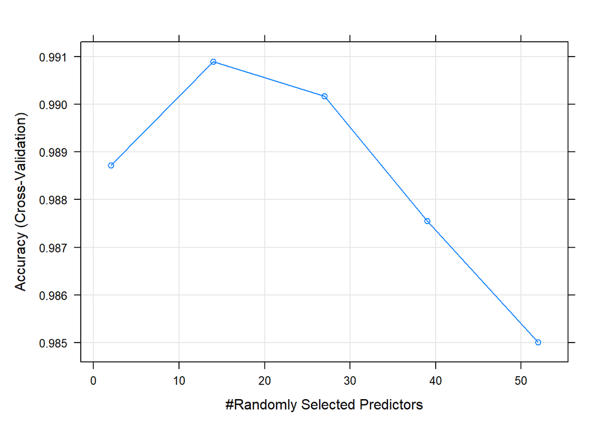

```r
plot(randomForest)
```

#### Decision Tree

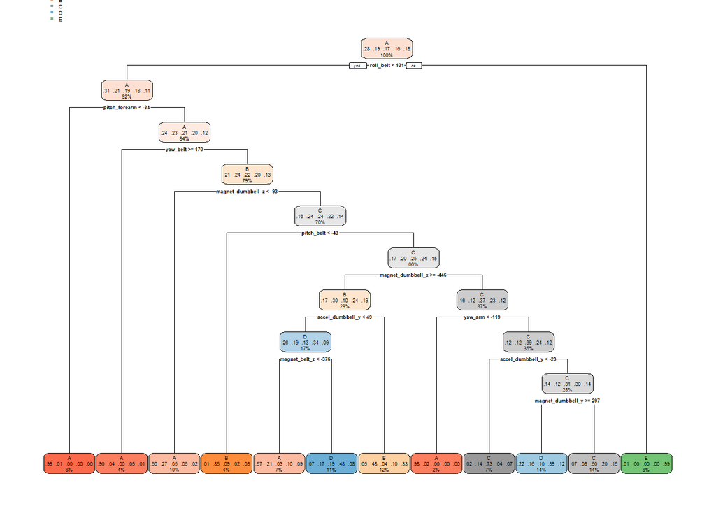

```r
dec_tree <- train(classe ~ ., data=train, method="rpart", tuneLength = 5)
rpart.plot(dec_tree$finalModel)
```

```r
prediction_tree <- predict(dec_tree, valid)
result_tree <- confusionMatrix(prediction_tree, factor(valid$classe))
result_tree
```

```
## Confusion Matrix and Statistics
##
##           Reference
## Prediction    A    B    C    D    E
##          A 1323  265   44   84   70
##          B   39  530   51   70  219
##          C   77  125  735  171  131
##          D  229  219  196  639  176
##          E    6    0    0    0  486
##
## Overall Statistics
##
##                Accuracy : 0.6309
##                  95% CI : (0.6184, 0.6433)
##     No Information Rate : 0.2845
##     P-Value [Acc > NIR] : < 2.2e-16
##
##                   Kappa : 0.5335
##
##  Mcnemar's Test P-Value : < 2.2e-16
##
## Statistics by Class:
##
##                      Class: A Class: B Class: C Class: D Class: E
## Sensitivity            0.7903  0.46532   0.7164   0.6629  0.44917
## Specificity            0.8900  0.92014   0.8963   0.8334  0.99875
## Pos Pred Value         0.7408  0.58306   0.5932   0.4380  0.98780
## Neg Pred Value         0.9144  0.87761   0.9374   0.9266  0.88949
## Prevalence             0.2845  0.19354   0.1743   0.1638  0.18386
## Detection Rate         0.2248  0.09006   0.1249   0.1086  0.08258
## Detection Prevalence   0.3035  0.15446   0.2105   0.2479  0.08360
## Balanced Accuracy      0.8402  0.69273   0.8063   0.7481  0.72396
```

#### Predict test results with Random Forest

```r
prediction <- predict(randomForest, testFile)
print(prediction)
```

```
##  [1] B A B A A E D B A A B C B A E E A B B B
## Levels: A B C D E
```

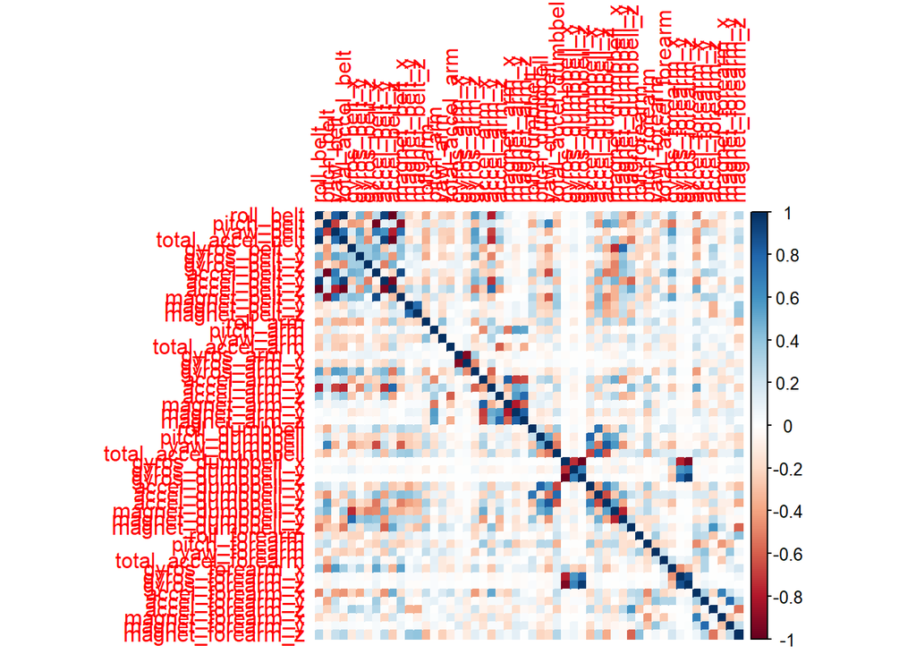

```r
correlation_Plot <- cor(train[, -length(names(train))])
corrplot(correlation_Plot, method="color")
```